# General_EDA_FeaturesSelection

```python
import pandas as pd
import numpy as np
import matplotlib.pyplot as plt
%matplotlib inline
import seaborn as sns
import datetime
from sklearn.preprocessing import scale
from sklearn.linear_model import Ridge, RidgeCV, Lasso, LassoCV
from sklearn.metrics import mean_squared_error

dataset=pd.read_excel(r'C:\Users\Dell\Desktop\BIBirbal\Sales-Modified-Superstore-Ver-5.xlsx')

df=dataset.rename(columns={'Customer ID':'Customer_ID','Customer Name':'Customer_Name','Order Date ':'Order_Date','Ship Date':'Ship_Date','Credit Days':'Credit_Days','Ship Mode':'Ship_Mode','Payment Date':'Payment_Date','Product ID':'Product_ID','Product Name':'Product_Name','Region ':'Region','Sub-Category':'Sub_Category','Discount (in %)':'Discount_inPercentage','Sales Person ID':'Sales_Person_ID','Sales Person Name':'Sales_Person_Name','Order ID':'Order_ID'})

df['year_month']=df['Order_Date'].apply(lambda x: x.strftime('%Y-%m'))
```

```python
df['Customer_ID_coded']=df['Customer_ID'].replace(['AP-2431', 'DS-4478', 'DM-5973', 'DM-3193', 'DB-3304', 'DN-2602',
       'JG-2062', 'DP-3309', 'AD-3053', 'HS-5864', 'AN-1988', 'DP-5650',
       'AH-3226', 'DP-2276', 'AK-6184', 'AP-4463', 'AP-2002', 'AP-3118',
       'JC-6502', 'AS-1715', 'DP-3783', 'JG-2969', 'DP-2380', 'JA-6154',
       'AS-3551', 'HP-2634', 'HP-0450', 'AM-1076', 'AP-4821', 'AS-4435',
       'DP-3851', 'DK-4670', 'AG-5945', 'AM-3664', 'AP-3784', 'AN-5654',
       'DP-0223', 'DP-5652', 'AM-4830', 'DP-6530', 'DP-5742', 'AP-6528',
       'HM-4687', 'HS-4832', 'DP-1620', 'AI-3526', 'DP-2519', 'JB-0380',
       'AA-3579', 'DK-3597', 'HS-1649', 'JC-1753', 'HM-3069', 'DN-5568',
       'AV-0972', 'DC-6215', 'AN-4599', 'AS-2829', 'JD-6087', 'HN-0481',
       'AS-0616', 'DI-4871', 'DP-6163', 'AD-3729', 'AD-4846', 'DC-5227',
       'HM-4254', 'AP-4886', 'AM-5123', 'AB-2095', 'DR-2271', 'AM-6204',
       'HV-4143', 'DI-5095', 'AM-4442', 'DD-2134', 'AP-6047', 'DV-3415',
       'AP-1364', 'AM-4494', 'AS-6288', 'DV-3613', 'DP-5899', 'AG-2804',
       'AK-0004', 'AN-0394', 'AG-4411', 'DV-1221', 'HP-4966', 'AP-4922',
       'HM-4278', 'DN-0701', 'AM-1700', 'JC-6300', 'DI-1810', 'AR-3000',
       'AM-3185', 'AI-4100', 'JG-1514', 'DS-4357', 'AI-4909', 'AM-3540',
       'DP-3057', 'AM-1281', 'AS-4982', 'AP-0796', 'AN-3205', 'AN-3392',
       'AP-2628', 'DP-2864', 'DN-6320', 'DI-4095', 'AP-2215', 'HP-2714',
       'DP-2832', 'DP-5245', 'AA-0124', 'DB-5136', 'AP-0270', 'DD-2336',
       'JB-6187', 'DG-5855', 'HB-1805', 'AD-1311', 'DG-5375', 'DS-3052',
       'DP-4557', 'DD-5582', 'JC-0621', 'AR-6515', 'AV-0925', 'HC-0986',
       'HI-6219', 'AS-0057', 'HM-5367', 'AG-4320', 'AP-5814', 'DS-3038',
       'HL-2267', 'JG-1461', 'DA-5485', 'DV-1600', 'DS-1211', 'DC-5637',
       'AV-3991', 'HP-0858', 'AR-3517', 'DP-2278', 'DI-4755', 'HS-6266',
       'AP-4413', 'AI-4022', 'DS-5320', 'HS-0002', 'AV-6150', 'DP-5996',
       'AC-1819', 'AK-2923', 'AA-0342', 'AN-6429', 'AC-5201', 'JC-5673',
       'DK-1301', 'AN-3711', 'DK-1757', 'AL-2439', 'AC-1580', 'DP-0093',
       'DP-4260', 'AR-0276', 'AD-2835', 'AP-2650', 'DM-1271', 'AS-1095',
       'DK-0941', 'DG-6440', 'DB-2121', 'AG-0653', 'AN-1540', 'DC-5724',
       'DP-5491', 'DS-3725', 'AA-2393', 'AK-5098', 'DS-1258', 'AP-3725',
       'AR-1051', 'AS-2807', 'HR-1826', 'AN-3350', 'DS-1971', 'HM-4036',
       'AC-0492', 'AR-6135', 'DS-2065', 'HG-3537', 'AI-4508', 'JG-2485',
       'AS-0851', 'AC-0949', 'AP-4638', 'DR-0867', 'AD-3632', 'DS-6213',
       'AM-2971', 'DS-0493', 'AL-0416', 'JD-1384', 'AP-6472', 'AV-1253',
       'JB-4481', 'HD-1205', 'DN-0171', 'DP-3921', 'AL-4504', 'AP-5728',
       'AP-4774', 'AS-0472', 'HI-3039', 'AV-5991', 'AM-0303', 'AS-1048',
       'AP-2574', 'DP-0728', 'DL-5486', 'DS-3036', 'DP-2125', 'AP-3668',
       'HS-2281', 'AV-0097', 'DM-3789', 'DM-6225', 'AV-4266', 'AP-3183',
       'AN-0634', 'DM-3633', 'HN-3893', 'DV-5846', 'HC-4552', 'AL-3791',
       'AI-5828', 'AS-0372', 'HM-3463', 'JG-2307', 'AK-1839', 'DR-2383',
       'AN-1575', 'HA-5819', 'AI-5184', 'AN-3580', 'AM-6130', 'AP-6245',
       'AS-1716', 'HS-0619', 'DI-2577', 'DS-5051', 'HN-1157', 'AP-0156',
       'AR-2121', 'AS-6370', 'DN-1710', 'AN-0002', 'DR-3777', 'JA-5141',
       'AS-5795', 'AP-2889', 'AA-2408', 'AK-6364', 'AP-2009', 'DM-2013',
       'DR-3563', 'AR-2805', 'DM-1467', 'AM-1518', 'HM-2070', 'AP-1806',
       'AS-0784', 'DV-1912', 'AG-1746', 'DP-3439', 'AI-0569', 'AP-4443',
       'DP-3083', 'DN-1577', 'AP-0185', 'AP-2602', 'AP-2273', 'AP-5311',
       'AG-5091', 'DP-0956', 'AP-3607', 'AI-5793', 'AR-1640', 'AP-2632',
       'DP-0327', 'AV-3515', 'AB-5215', 'DN-2933', 'DS-6132', 'AG-4081',
       'DS-0754', 'HS-3060', 'AI-2853', 'AC-6438', 'AV-5603', 'AM-1505',
       'AP-5223', 'DI-2927', 'HV-4119', 'AM-2465', 'HB-5062', 'DN-3069',
       'AS-2362', 'AP-5158', 'AB-2909', 'AV-6313', 'AC-4949', 'DP-5490',
       'DI-2595', 'AM-5101', 'HP-1795', 'DL-6043', 'AG-2039', 'AG-4527',
       'JD-0122', 'AS-3538', 'AG-3439', 'DR-4247', 'AI-5212', 'JD-4968',
       'AN-1639', 'HS-3377', 'HK-5966', 'AS-0661', 'HD-1323', 'JB-1018',
       'DM-2334', 'DM-5858', 'DM-5228', 'JG-0066', 'AC-3032', 'AP-4020',
       'DN-3552', 'AV-1964', 'AR-5726', 'AN-1887', 'AM-0717', 'AP-0567',
       'DG-6487', 'AN-2209', 'JD-1162', 'AP-0645', 'DM-0266', 'AN-0688',
       'AP-0273', 'DC-0250', 'HD-4591', 'DV-3911', 'AD-5537', 'DB-5758',
       'AP-3431', 'HA-4624', 'DA-0500', 'DP-3864', 'AS-5736', 'AP-6192',
       'DD-4349', 'DS-4640', 'JG-3320', 'AM-3045', 'AS-1427', 'DV-2463',
       'AG-4003', 'HP-4442', 'DM-3622', 'DG-4832', 'DP-2876', 'DR-2290',
       'DS-4933', 'JG-2011', 'AP-1562', 'JA-1409', 'DM-2501', 'AI-5277',
       'DM-0422', 'DG-1021', 'HR-5262', 'DM-5999', 'DI-5012', 'DP-3014',
       'HK-5890', 'DK-5360', 'AP-1889', 'AM-2623', 'HP-1113', 'DM-5077',
       'AI-6045', 'DS-5572', 'JA-1997', 'DM-5116', 'AP-3580', 'DA-3294',
       'DS-0337', 'AS-4162', 'AD-3873', 'AS-4552', 'AP-2262', 'DN-3476',
       'AC-4367', 'AS-4087', 'AP-5422', 'DN-1812', 'AV-4580', 'DS-1432',
       'AP-5395', 'DM-5468', 'AP-2346', 'HM-3583', 'AS-1243', 'AT-1075',
       'DL-6496', 'HP-4670', 'JG-1044', 'AG-2059', 'JC-0272', 'DC-0695',
       'JD-1692', 'AS-5409', 'DP-3686', 'AI-3356', 'DP-5122', 'AN-2627',
       'DG-5719', 'JC-0115', 'AS-0687', 'DG-5125', 'HP-5168', 'DL-4945',
       'AP-3887', 'DI-6434', 'AP-0013', 'AP-2236', 'AP-5394', 'AK-4141',
       'AG-0512', 'AP-2413', 'HC-1129', 'AP-0377', 'AS-5140', 'AI-0663',
       'AD-4270', 'JC-3133', 'AP-5554', 'AS-6431', 'AS-0847', 'AK-1789',
       'JG-3163', 'HR-4700', 'AS-5573', 'AS-1279', 'JB-2082', 'AB-5959',
       'DM-3335', 'JB-0181', 'AG-2211', 'DM-3107', 'AS-3497', 'AS-6385',
       'HI-2797', 'AP-4730', 'AP-6013', 'DM-2988', 'HP-1264', 'DN-4700',
       'AN-3827', 'AD-1194', 'HB-6361', 'JC-6530', 'AL-3074', 'DP-5511',
       'AR-1458', 'AD-4271', 'AB-5373', 'DP-6459', 'DH-6342', 'DS-3388',
       'AP-0449', 'DS-4234', 'AV-5473', 'HP-3634', 'JA-1235', 'AP-2266',
       'JB-3362', 'DP-3031', 'JG-2655', 'JC-0327', 'DN-1907', 'AI-4101',
       'JB-1744', 'AI-4023', 'DS-3165', 'JD-3337', 'DG-4569', 'HD-4239',
       'AN-4501', 'DP-1747', 'AV-6008', 'AM-5243', 'HI-0368', 'AS-6208',
       'DS-0750', 'HG-1867', 'AC-5616', 'AB-2781', 'AS-5435', 'JG-3095',
       'DV-3126', 'DV-0466', 'AB-4279', 'AV-5264', 'AS-4703', 'DP-1420',
       'DA-6117', 'AS-0256', 'AN-5983', 'AC-0156', 'AP-0502', 'AV-3961',
       'HN-1455', 'JB-3011', 'HS-0489', 'HS-2155', 'DS-1053', 'HP-4899',
       'DP-6132', 'AS-2857', 'AP-1129', 'DP-6113', 'AG-3548', 'AG-1135',
       'AI-3658', 'DP-2532', 'AL-6426', 'DN-1530', 'AK-5585', 'AD-0730',
       'JC-5535', 'AP-2460', 'DN-2380', 'DI-4332', 'DM-6491', 'AP-5023',
       'AN-0358', 'AP-1359', 'DV-5962', 'DP-5225', 'HG-3197', 'AS-4266',
       'AP-6299', 'JA-2186', 'JA-3523', 'AP-0644', 'HP-2907', 'AN-3615',
       'DM-0858', 'DV-1388', 'DG-1750', 'HS-4682', 'AN-1519', 'HS-0209',
       'AM-2369', 'HN-3242', 'HP-3766', 'HN-0227', 'AP-3951', 'DP-1496',
       'AS-3821', 'DS-5377', 'JD-1114', 'AA-5942', 'DI-3712', 'JD-3319',
       'HP-1191', 'AM-3097', 'AM-4766', 'DN-5147', 'JA-2760', 'AP-0226',
       'DN-5603', 'HC-1737', 'DG-0628', 'DN-3417', 'AD-6490', 'DS-1096',
       'AV-5719', 'AM-2016', 'AD-0936', 'AC-2457', 'JG-3144', 'AN-3162',
       'DI-4878', 'AN-1444', 'HM-0848', 'JD-1286', 'DM-1638', 'HP-4068',
       'AS-0578', 'DK-3686', 'DR-2140', 'JC-5434', 'AP-1250', 'AD-0368',
       'AV-3004', 'AP-0837', 'JB-5558', 'AP-3642', 'AM-6087', 'AS-5453',
       'DB-5752', 'AM-6144', 'AM-0424', 'DD-0907', 'AN-5460', 'AP-6346',
       'AK-2906', 'AM-0278', 'AM-5540', 'DP-2752', 'AS-4852', 'HB-4130',
       'AG-4011', 'AS-1591', 'AP-3871', 'JC-3352', 'DP-2834', 'DS-0410',
       'AV-5279', 'DM-2642', 'DD-0073', 'AN-4688', 'AS-4420', 'DK-1618',
       'HV-2071', 'AC-3946', 'HI-2751', 'AV-2204', 'DP-6340', 'AP-5308',
       'AG-6316', 'AG-5688', 'DP-2078', 'AM-3756', 'AK-1983', 'AG-4674',
       'AP-4975', 'DP-1356', 'AR-0524', 'AV-1695', 'AP-5516', 'HP-5490',
       'HN-6050', 'HV-5262', 'AM-3996', 'HG-2476', 'AI-0748', 'JG-1791',
       'DI-2666', 'AP-6209', 'JD-3517', 'JC-5584', 'HG-2511', 'AI-2746',
       'DS-4067', 'AP-5212', 'AN-6022', 'DS-4393', 'JD-2446', 'DD-0170',
       'HN-1074', 'AP-2444', 'DV-5215', 'AP-5944', 'DI-5605', 'AM-1251',
       'AM-2934', 'DR-0197', 'AK-1477', 'DG-5169', 'AI-5538', 'AB-5818',
       'DP-2731', 'DC-1690', 'AA-3612', 'AM-5852', 'HP-3937', 'AM-5495',
       'AP-2627', 'AL-2317', 'AS-2886', 'AP-5114', 'AS-2690', 'AV-3447',
       'AR-2353', 'HR-2170', 'AM-3816', 'AS-6294', 'DP-4020', 'HP-1489',
       'DG-1313', 'AP-4133', 'AM-1959', 'DP-3662', 'AP-2421', 'DP-4270',
       'AR-2764', 'DS-0566', 'DD-5527', 'JC-4015', 'HG-2100', 'DP-0557',
       'HS-5741', 'AC-0178', 'JD-2736', 'HP-0249', 'AP-0660', 'DS-3921',
       'AP-5303', 'AP-5354', 'DC-1466', 'AP-2141', 'AL-4464', 'AK-0447',
       'AP-3794', 'AS-4385', 'AI-1623', 'JA-5145', 'AS-0901', 'AI-1820',
       'AP-3205', 'AV-0825', 'AM-4406', 'AI-1361', 'AS-3073', 'HV-3771',
       'AY-3830', 'DV-3285', 'HV-4568', 'DA-4818', 'AN-0534', 'AP-4951',
       'AM-5167', 'DV-3639', 'AM-5953', 'HP-5026', 'DM-4422', 'AN-3528',
       'AG-3392', 'AM-2799', 'HM-2109', 'HM-4776', 'DM-2182', 'HL-3492',
       'AP-2850', 'DC-5460', 'JA-2057', 'DL-4760', 'DS-1706', 'AG-1528',
       'DK-0950', 'AC-1804', 'DP-1825', 'AD-4392', 'DP-1282', 'AM-5809',
       'HP-0316', 'AG-2084', 'HK-1864', 'DR-3124', 'AM-3541', 'HP-4571',
       'AS-6195', 'AM-4394'],range(1,783))
df['Ship_Mode_coded']=df['Ship_Mode'].replace(['Standard Class', 'Second Class', 'First Class', 'Same Day'],[1,2,3,4])
df['City_coded']=df['City'].replace(['Darbhanga', 'Koraput', 'Bhubaneshwar', 'Palakkad', 'Hazaribag',
       'Vishakhapatnam', 'Gaya', 'Bilaspur', 'Kochi', 'Karimganj ',
       'Jorhat', 'Ludhiana', 'Jalandhar', 'Karwar', 'Jalgaon',
       'Muzaffarpur', 'Daman', 'Mangalore', 'Gorakhpur', 'Surat',
       'Bikaner', 'Karimnagar', 'Jamshedpur', 'Jaisalmer', 'Hoshiarpur',
       'Guwahati', 'Dharamshala', 'Thrissur', 'Puri', 'Solan', 'Nagpur',
       'Deoghar', 'Belgaum', 'Agra', 'Jaipur', 'Guntur', 'Aurangabad',
       'Jagdalpur', 'Varanasi', 'Kanpur', 'Chennai', 'Indore', 'Pasighat',
       'Narsinghpur', 'Ambala', 'Gandhinagar', 'Ranchi', 'Shimla', 'Diu',
       'Kozhikode', 'Amravati', 'Faridabad', 'Bharuch', 'Bokaro', 'Patna',
       'Medak', 'Ahemdabad', 'Durg', 'Mumbai', 'Dehradun', 'Uttarkashi',
       'Mysore', 'Bardhaman', 'Hyderabad', 'Gurgaon', 'Tezpur',
       'Kolhapur', 'Chamba', 'Ukhrul', 'Dharwad', 'Bhagalpur', 'Chittor',
       'Alappuzha', 'Sambalpur', 'Coimbatore', 'Kottayam', 'Ajmer',
       'Kakinada', 'Tezu', 'Munger', 'Dhanbad', 'Rajnandgaon', 'Cuttack',
       'Hissar', 'Nizamabad', 'Delhi', 'Jammu', 'Kolkatta', 'Darjeeling',
       'Thiruvananthapuram', 'Imphal', 'Raipur', 'Rohtak', 'Korba',
       'Srinagar', 'Anantpur', 'Jodhpur', 'Dibrugarh', 'Vellore', 'Kullu',
       'Panipat', 'Gwalior', 'Chandigarh', 'Rajkot', 'Ahmedabad',
       'Jabalpur', 'Madurai', 'Bishnupur', 'Gangtok', 'Bhilwara',
       'Jalpaiguri', 'Ujjain', 'Bangalore', 'Ghaziabad', 'Kolkata',
       'Khandwa', 'Bhopal', 'Salem', 'Midnapore', 'Lucknow', 'Haridwar',
       'Noida', 'Allahabad', 'Amritsar', 'Vadodara', 'Asansol',
       'Tiruchirappalli'],range(1,128))
df['State_coded']=df['State'].replace(['Bihar', 'Odisha', 'Kerala', 'Jharkhand', 'Andhra Pradesh',
       'Chhattisgarh', 'Assam', 'Punjab', 'Karnataka', 'Maharashtra',
       'Daman', 'Uttar Pradesh', 'Gujarat', 'Rajasthan', 'Telangana',
       'Himachal Pradesh', 'Tamil Nadu', 'Madhya Pradesh',
       'Arunachal Pradesh', 'Haryana', 'Diu', 'Uttarakhand',
       'West Bengal', 'Manipur', 'Delhi', 'Jammu & Kashmir', 'Sikkim'],range(1,28))
df['Region_coded']=df['Region'].replace(['East','West','South','North','Central'],[1,2,3,4,5])
df['Segment_coded']=df['Segment'].replace(['Consumer', 'Home Office', 'Corporate'],[1,2,3])
```

```python
df['Category_coded']=df['Category'].replace(['Technology','Office Supplies', 'Furniture'],[1,2,3])
df['Sub_Category_coded']=df['Sub_Category'].replace(['Phones','Copiers','Accessories','Machines','Binders','Paper','Storage','Appliances','Envelopes','Art','Labels','Fasteners','Supplies','Chairs','Furnishings','Bookcases','Tables'],range(1,18))
df['Unit_Price']=(df['Sales']/df['Quantity'])/(1-df['Discount_inPercentage'])
df['year_month_coded']=df['year_month'].replace(['2016-01', '2016-02', '2016-03', '2016-04', '2016-05', '2016-06',
       '2016-07', '2016-08', '2016-09', '2016-10', '2016-11', '2016-12',
       '2017-01', '2017-02', '2017-03', '2017-04', '2017-05', '2017-06',
       '2017-07', '2017-08', '2017-09', '2017-10', '2017-11', '2017-12',
       '2018-01', '2018-02', '2018-03', '2018-04', '2018-05', '2018-06',
       '2018-07', '2018-08', '2018-09', '2018-10', '2018-11', '2018-12'],range(1,37))
df['Sales_Person_ID_coded']=df['Sales_Person_ID'].replace(['AR-6564', 'AR-6561', 'JD-6618', 'SV-6663', 'RH-6633', 'RP-6636',
       'SV-6654', 'DD-6597', 'SV-6639', 'SV-6648', 'SG-6666', 'JD-6615',
       'AR-6555', 'SG-6657', 'ND-6624', 'DG-6585', 'SV-6651', 'RR-6630',
       'VS-6672', 'AR-6540', 'AC-6543', 'JD-6609', 'DK-6576', 'DG-6573',
       'DG-6582', 'DB-6579', 'DM-6603', 'AA-6546', 'AR-6570', 'AA-6558',
       'AB-6567', 'AA-6552', 'JG-6612', 'SV-6645', 'VS-6675', 'DG-6588',
       'ND-6627', 'DD-6591', 'SV-6642', 'SV-6660', 'JD-6606', 'VP-6669',
       'DM-6600', 'ND-6621', 'VV-6678', 'VP-6681', 'DK-6594', 'AI-6549'],range(1,49))
```

```python
data=df.drop(columns=['Customer_ID_coded','Ship_Mode_coded','year_month_coded', 'City_coded', 'State_coded', 'Region_coded','Segment_coded', 'Category_coded', 'Sub_Category_coded','Sales_Person_ID_coded'])
print("data columns:   ", data.columns)

data_coded=df.drop(columns=['Customer_ID','Product_ID','Ship_Mode','City','State','Region','Segment','Category','Sub_Category','Sales_Person_ID'])
print("data_coded columns:   ",data_coded.columns)
```

```
data columns:    Index(['Customer_ID', 'Customer_Name', 'Order_Date', 'Ship_Date',
       'Credit_Days', 'Ship_Mode', 'Payment_Date', 'Product_ID',
       'Product_Name', 'City', 'State', 'Region', 'Country', 'Segment',
       'Category', 'Sub_Category', 'Quantity', 'Sales', 'Profit',
       'Discount_inPercentage', 'Sales_Person_ID', 'Sales_Person_Name',
       'Order_ID', 'year_month', 'Unit_Price'],
      dtype='object')
data_coded columns:    Index(['Customer_Name', 'Order_Date', 'Ship_Date', 'Credit_Days',
       'Payment_Date', 'Product_Name', 'Country', 'Quantity', 'Sales',
       'Profit', 'Discount_inPercentage', 'Sales_Person_Name', 'Order_ID',
       'year_month', 'Customer_ID_coded', 'Ship_Mode_coded', 'City_coded',
       'State_coded', 'Region_coded', 'Segment_coded', 'Category_coded',
       'Sub_Category_coded', 'Unit_Price', 'year_month_coded',
       'Sales_Person_ID_coded'],
      dtype='object')
```

```python
#data.to_excel(r'C:\Users\Dell\Desktop\BIBirbal\data.xlsx',index=None,header=True)
```

```python
#data_coded.to_excel(r'C:\Users\Dell\Desktop\BIBirbal\data_coded.xlsx',index=None,header=True)
```

```python
data.shape
```

```
(6682, 25)
```

```python
data_coded.shape
```

```
(6682, 25)
```

```python
data.info()
```

```
<class 'pandas.core.frame.DataFrame'>
RangeIndex: 6682 entries, 0 to 6681
Data columns (total 25 columns):
 #   Column                 Non-Null Count  Dtype
---  ------                 --------------  -----
 0   Customer_ID            6682 non-null   object
 1   Customer_Name          6682 non-null   object
 2   Order_Date             6682 non-null   datetime64[ns]
 3   Ship_Date              6682 non-null   datetime64[ns]
 4   Credit_Days            6682 non-null   int64
 5   Ship_Mode              6682 non-null   object
 6   Payment_Date           6682 non-null   datetime64[ns]
 7   Product_ID             6682 non-null   object
 8   Product_Name           6682 non-null   object
 9   City                   6682 non-null   object
```

[output cut: 17 more lines]

```python
data.describe()
```

|  | Credit_Days | Quantity | Sales | Profit | Discount_inPercentage | Unit_Price |
| --- | --- | --- | --- | --- | --- | --- |
| count | 6682.000000 | 6682.000000 | 6.682000e+03 | 6.682000e+03 | 6682.000000 | 6.682000e+03 |
| mean | 39.201586 | 3.800808 | 1.497981e+05 | 1.848144e+04 | 0.156072 | 4.862942e+04 |
| std | 7.304970 | 2.226841 | 4.103946e+05 | 1.474663e+05 | 0.205981 | 1.205168e+05 |
| min | 30.000000 | 1.000000 | 5.350400e+02 | -4.223986e+06 | 0.000000 | 6.336000e+02 |
| 25% | 30.000000 | 2.000000 | 1.110400e+04 | 1.088256e+03 | 0.000000 | 4.147200e+03 |
| 50% | 45.000000 | 3.000000 | 3.514240e+04 | 5.629920e+03 | 0.200000 | 1.278720e+04 |
| 75% | 45.000000 | 5.000000 | 1.362048e+05 | 1.918973e+04 | 0.200000 | 5.080960e+04 |
| max | 45.000000 | 14.000000 | 1.448863e+07 | 5.375985e+06 | 0.800000 | 4.829542e+06 |

```python
data.isnull().sum()
```

```
Customer_ID              0
Customer_Name            0
Order_Date               0
Ship_Date                0
Credit_Days              0
Ship_Mode                0
Payment_Date             0
Product_ID               0
Product_Name             0
City                     0
State                    0
Region                   0
Country                  0
Segment                  0
Category                 0
Sub_Category             0
Quantity                 0
Sales                    0
Profit                   0
Discount_inPercentage    0
Sales_Person_ID          0
Sales_Person_Name        0
Order_ID                 0
year_month               0
Unit_Price               0
dtype: int64
```

```python
data['Order_Date'].min()
```

```
Timestamp('2016-01-03 00:00:00')
```

```python
data['Order_Date'].max()
```

```
Timestamp('2018-12-31 00:00:00')
```

```python
data_trend=data.groupby('year_month').sum()['Sales'].reset_index()
data_trend.head()
```

|  | year_month | Sales |
| --- | --- | --- |
| 0 | 2016-01 | 9111612.80 |
| 1 | 2016-02 | 2892730.88 |
| 2 | 2016-03 | 35642245.76 |
| 3 | 2016-04 | 18109020.80 |
| 4 | 2016-05 | 15134903.68 |

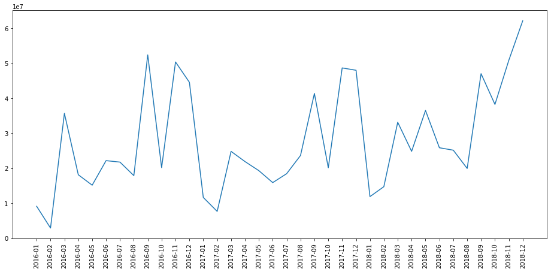

```python
plt.figure(figsize=(16,7))
plt.plot(data_trend['year_month'],data_trend['Sales'])
plt.xticks(rotation='vertical',size=10)
plt.show()
```

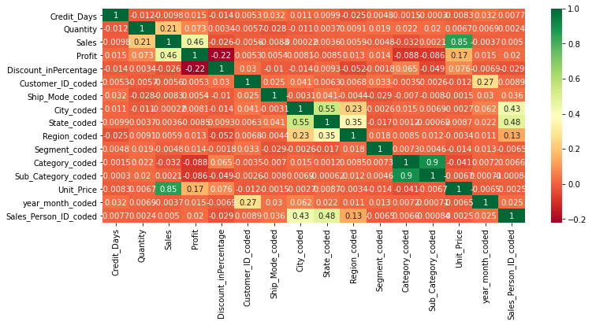

```python
corrmat=data_coded.corr()
top_corr=corrmat.index
plt.figure(figsize=(12,5))
#plot the heatmap
g=sns.heatmap(data_coded[top_corr].corr(),annot=True,cmap='RdYlGn')
```

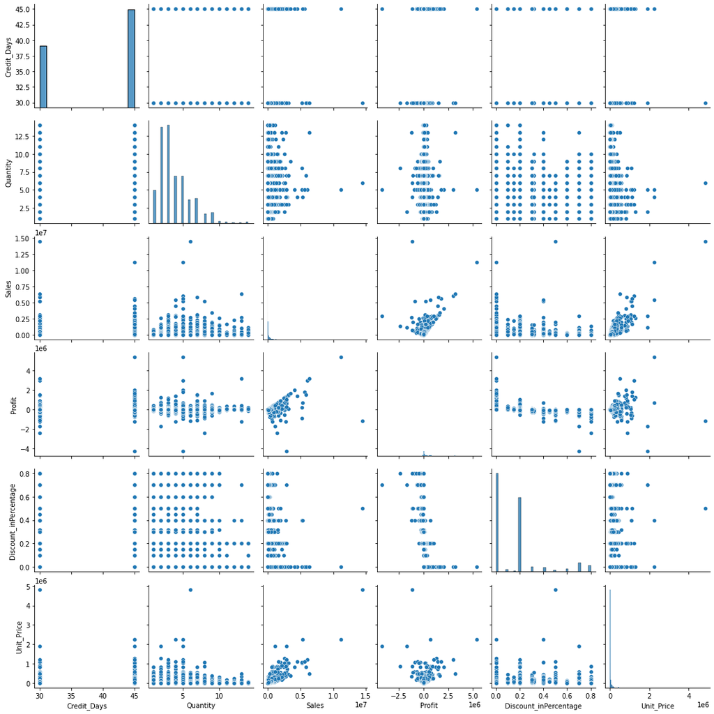

```python
sns.pairplot(data)
```

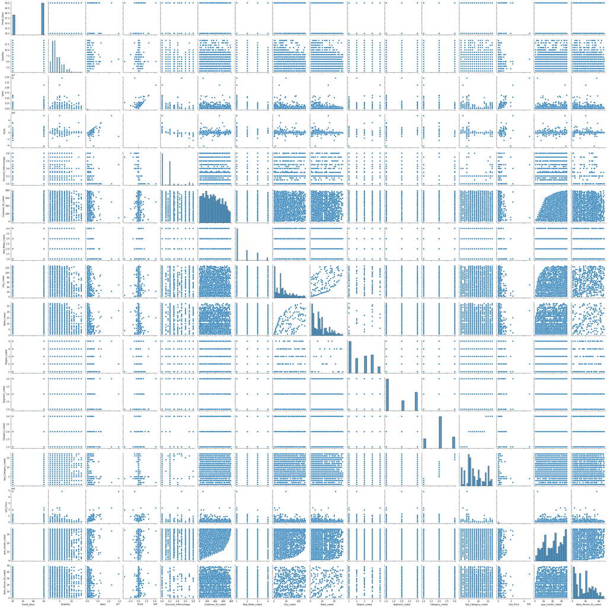

```python
sns.pairplot(data_coded)
```

### Features Selection

```python
data_coded.shape
```

```
(6682, 25)
```

```python
from sklearn.model_selection import train_test_split
from sklearn.ensemble import RandomForestRegressor,RandomForestClassifier
from sklearn.metrics import roc_auc_score
from mlxtend.feature_selection import SequentialFeatureSelector as SFS
from sklearn.preprocessing import StandardScaler
```

```python
data_coded.keys()
```

```
Index(['Customer_Name', 'Order_Date', 'Ship_Date', 'Credit_Days',
       'Payment_Date', 'Product_Name', 'Country', 'Quantity', 'Sales',
       'Profit', 'Discount_inPercentage', 'Sales_Person_Name', 'Order_ID',
       'year_month', 'Customer_ID_coded', 'Ship_Mode_coded', 'City_coded',
       'State_coded', 'Region_coded', 'Segment_coded', 'Category_coded',
       'Sub_Category_coded', 'Unit_Price', 'year_month_coded',
       'Sales_Person_ID_coded'],
      dtype='object')
```

```python
y = data_coded['Sales']
X = data_coded[data_coded.columns.difference(['Sales'])]
```

```python
X_train,X_test,y_train,y_test=train_test_split(X,y,test_size=0.2,random_state=0)
X_train.shape , X_test.shape
```

```
((5345, 24), (1337, 24))
```

### Step Forward Selection (SFS)

```python
sfs=SFS(RandomForestClassifier(n_estimators=100, random_state=0, n_jobs= -1),
       k_features =24,
       forward= True,
       floating= False,
       verbose=2,
       scoring='accuracy',
       cv=4,
       n_jobs= -1,
       ).fit(X_train,y_train)
```

[output not shown]

[output cut: 28 more lines]

[output not shown]

```python
sfs.k_feature_names_
```

```
('Category_coded',
 'City_coded',
 'Country',
 'Credit_Days',
 'Customer_ID_coded',
 'Customer_Name',
 'Discount_inPercentage',
 'Order_Date',
 'Order_ID',
 'Payment_Date',
 'Product_Name',
 'Profit',
 'Quantity',
 'Region_coded',
 'Sales_Person_ID_coded',
 'Sales_Person_Name',
 'Segment_coded',
 'Ship_Date',
 'Ship_Mode_coded',
 'State_coded',
 'Sub_Category_coded',
 'Unit_Price',
 'year_month',
 'year_month_coded')
```

```python
sfs.k_score_
```

```
nan
```

```python
pd.DataFrame.from_dict(sfs.get_metric_dict()).T
```

|  | feature_idx | cv_scores | avg_score | feature_names | ci_bound | std_dev | std_err |
| --- | --- | --- | --- | --- | --- | --- | --- |
| 1 | (0,) | [nan, nan, nan, nan] | NaN | (Category_coded,) | NaN | NaN | NaN |
| 2 | (0, 1) | [nan, nan, nan, nan] | NaN | (Category_coded, City_coded) | NaN | NaN | NaN |
| 3 | (0, 1, 2) | [nan, nan, nan, nan] | NaN | (Category_coded, City_coded, Country) | NaN | NaN | NaN |
| 4 | (0, 1, 2, 3) | [nan, nan, nan, nan] | NaN | (Category_coded, City_coded, Country, Credit_D... | NaN | NaN | NaN |
| 5 | (0, 1, 2, 3, 4) | [nan, nan, nan, nan] | NaN | (Category_coded, City_coded, Country, Credit_D... | NaN | NaN | NaN |
| 6 | (0, 1, 2, 3, 4, 5) | [nan, nan, nan, nan] | NaN | (Category_coded, City_coded, Country, Credit_D... | NaN | NaN | NaN |
| 7 | (0, 1, 2, 3, 4, 5, 6) | [nan, nan, nan, nan] | NaN | (Category_coded, City_coded, Country, Credit_D... | NaN | NaN | NaN |
| 8 | (0, 1, 2, 3, 4, 5, 6, 7) | [nan, nan, nan, nan] | NaN | (Category_coded, City_coded, Country, Credit_D... | NaN | NaN | NaN |
| 9 | (0, 1, 2, 3, 4, 5, 6, 7, 8) | [nan, nan, nan, nan] | NaN | (Category_coded, City_coded, Country, Credit_D... | NaN | NaN | NaN |
| 10 | (0, 1, 2, 3, 4, 5, 6, 7, 8, 9) | [nan, nan, nan, nan] | NaN | (Category_coded, City_coded, Country, Credit_D... | NaN | NaN | NaN |
| 11 | (0, 1, 2, 3, 4, 5, 6, 7, 8, 9, 10) | [nan, nan, nan, nan] | NaN | (Category_coded, City_coded, Country, Credit_D... | NaN | NaN | NaN |
| 12 | (0, 1, 2, 3, 4, 5, 6, 7, 8, 9, 10, 11) | [nan, nan, nan, nan] | NaN | (Category_coded, City_coded, Country, Credit_D... | NaN | NaN | NaN |
| 13 | (0, 1, 2, 3, 4, 5, 6, 7, 8, 9, 10, 11, 12) | [nan, nan, nan, nan] | NaN | (Category_coded, City_coded, Country, Credit_D... | NaN | NaN | NaN |
| 14 | (0, 1, 2, 3, 4, 5, 6, 7, 8, 9, 10, 11, 12, 13) | [nan, nan, nan, nan] | NaN | (Category_coded, City_coded, Country, Credit_D... | NaN | NaN | NaN |
| 15 | (0, 1, 2, 3, 4, 5, 6, 7, 8, 9, 10, 11, 12, 13,... | [nan, nan, nan, nan] | NaN | (Category_coded, City_coded, Country, Credit_D... | NaN | NaN | NaN |
| 16 | (0, 1, 2, 3, 4, 5, 6, 7, 8, 9, 10, 11, 12, 13,... | [nan, nan, nan, nan] | NaN | (Category_coded, City_coded, Country, Credit_D... | NaN | NaN | NaN |
| 17 | (0, 1, 2, 3, 4, 5, 6, 7, 8, 9, 10, 11, 12, 13,... | [nan, nan, nan, nan] | NaN | (Category_coded, City_coded, Country, Credit_D... | NaN | NaN | NaN |
| 18 | (0, 1, 2, 3, 4, 5, 6, 7, 8, 9, 10, 11, 12, 13,... | [nan, nan, nan, nan] | NaN | (Category_coded, City_coded, Country, Credit_D... | NaN | NaN | NaN |
| 19 | (0, 1, 2, 3, 4, 5, 6, 7, 8, 9, 10, 11, 12, 13,... | [nan, nan, nan, nan] | NaN | (Category_coded, City_coded, Country, Credit_D... | NaN | NaN | NaN |
| 20 | (0, 1, 2, 3, 4, 5, 6, 7, 8, 9, 10, 11, 12, 13,... | [nan, nan, nan, nan] | NaN | (Category_coded, City_coded, Country, Credit_D... | NaN | NaN | NaN |
| 21 | (0, 1, 2, 3, 4, 5, 6, 7, 8, 9, 10, 11, 12, 13,... | [nan, nan, nan, nan] | NaN | (Category_coded, City_coded, Country, Credit_D... | NaN | NaN | NaN |
| 22 | (0, 1, 2, 3, 4, 5, 6, 7, 8, 9, 10, 11, 12, 13,... | [nan, nan, nan, nan] | NaN | (Category_coded, City_coded, Country, Credit_D... | NaN | NaN | NaN |
| 23 | (0, 1, 2, 3, 4, 5, 6, 7, 8, 9, 10, 11, 12, 13,... | [nan, nan, nan, nan] | NaN | (Category_coded, City_coded, Country, Credit_D... | NaN | NaN | NaN |
| 24 | (0, 1, 2, 3, 4, 5, 6, 7, 8, 9, 10, 11, 12, 13,... | [nan, nan, nan, nan] | NaN | (Category_coded, City_coded, Country, Credit_D... | NaN | NaN | NaN |

### Multiple Regression

```
   y = bo+ b1X1 + b2X2 + b3X3 + b4X4 + b5X5 + b6X6 + b7X7 + b8X8 + b9X9 + b10X10 + b11X11 + b12X12 + b13X13 + b14X14 + b15X15 + b16X16 + ei
where y is dependent variable ie., y= Sales
and Xi's are independent variable ie.,
                             b0=Intercept
X1=Category_coded               b1=coefficient of X1(=Category_coded)
X2=City_coded                   b2=coefficient of X2(=City_coded)
X3=Credit_Days                  b3=coefficient of X3(=Credit_Days)
X4=Customer_ID_coded            b4=coefficient of X4(=Customer_ID_coded)
X5=Discount_inPercentage        b5=coefficient of X5(=Discount_inPercentage)
X6=Order_Date                   b6=coefficient of X6(=Order_Date)
X7=Order_ID                     b7=coefficient of X7(=Order_ID)
X8=Product_Name                 b8=coefficient of X8(=Product_Name)
X9=Quantity                     b9=coefficient of X9(=Quantity)
X10=Region_coded                b10=coefficient of X10(=Region_coded)
X11=Sales_Person_ID_coded       b11=coefficient of X11(=Sales_Person_ID_coded)
X12=Ship_Mode_coded             b12=coefficient of X12(=Ship_Mode_coded)
X13=State_coded                 b13=coefficient of X13(=State_coded)
X14=Sub_Category_coded          b14=coefficient of X14(=Sub_Category_coded)
X15=Unit_Price                  b15=coefficient of X15(=Unit_Price)
X16=year_month_coded            b16=coefficient of X16(=year_month_coded)
```

To Test: (i) H0: Beta(i) = 0 vs. H1: Beta(i) != 0 where i=0,1,...,16.

(ii) H0: Model is not significant vs. H1: Model is significant

> Critical Region :If pvalue<0.05, so we reject our null hypothesis at 5% level of significance.

```python
# import statsmodels.formula.api as smf

# model=smf.ols("Sales ~ Category_coded + City_coded + Credit_Days + Customer_ID_coded + Discount_inPercentage + Order_Date + Order_ID + Product_Name + Quantity + Region_coded + Sales_Person_ID_coded + Segment_coded + Ship_Mode_coded + State_coded + Sub_Category_coded + Unit_Price + year_month_coded", data_coded)

# result = model.fit()

# result.summary()
```

```python
data_coded_Ridge=data_coded[['Category_coded','City_coded','Credit_Days','Customer_ID_coded','Sales',
                            'Discount_inPercentage','Quantity',
                            'Region_coded','Sales_Person_ID_coded','Segment_coded','Ship_Mode_coded',
                            'State_coded','Sub_Category_coded','Unit_Price','year_month_coded']]
```

```python
y = data_coded_Ridge['Sales']
X = data_coded_Ridge[data_coded_Ridge.columns.difference(['Sales'])]


X_train_Ridge, X_test_Ridge, y_train_Ridge, y_test_Ridge=X[:int(0.8*(len(X)))],X[int(0.8*(len(X))):],y[:int(0.8*(len(y)))],y[int(0.8*(len(y))):]
```

```python
from sklearn.metrics import mean_squared_error

model1 = Ridge(alpha = 10, normalize = False)
model1.fit(X_train_Ridge, y_train_Ridge)             # Fit a ridge regression on the training data
pred1 = model1.predict(X_test_Ridge)           # Use this model to predict the test data
print(pd.Series(model1.coef_, index = X.columns)) # Print coefficients
print(mean_squared_error(y_test_Ridge, pred1))          # Calculate the test MSE
```

```
Category_coded             8593.177825
City_coded                   91.715013
Credit_Days                 -15.434876
Customer_ID_coded             9.953441
Discount_inPercentage   -163285.170861
Quantity                  36042.892639
Region_coded                452.908343
Sales_Person_ID_coded       470.498254
Segment_coded              -166.422423
Ship_Mode_coded            -320.462136
State_coded               -1250.167467
Sub_Category_coded         -653.288996
Unit_Price                    2.857605
year_month_coded           -173.215144
dtype: float64
58791185495.057686
```

```python
alphas = 10**np.linspace(10,-2,100)*0.5
alphas
```

```
array([5.00000000e+09, 3.78231664e+09, 2.86118383e+09, 2.16438064e+09,
       1.63727458e+09, 1.23853818e+09, 9.36908711e+08, 7.08737081e+08,
       5.36133611e+08, 4.05565415e+08, 3.06795364e+08, 2.32079442e+08,
       1.75559587e+08, 1.32804389e+08, 1.00461650e+08, 7.59955541e+07,
       5.74878498e+07, 4.34874501e+07, 3.28966612e+07, 2.48851178e+07,
       1.88246790e+07, 1.42401793e+07, 1.07721735e+07, 8.14875417e+06,
       6.16423370e+06, 4.66301673e+06, 3.52740116e+06, 2.66834962e+06,
       2.01850863e+06, 1.52692775e+06, 1.15506485e+06, 8.73764200e+05,
       6.60970574e+05, 5.00000000e+05, 3.78231664e+05, 2.86118383e+05,
       2.16438064e+05, 1.63727458e+05, 1.23853818e+05, 9.36908711e+04,
       7.08737081e+04, 5.36133611e+04, 4.05565415e+04, 3.06795364e+04,
       2.32079442e+04, 1.75559587e+04, 1.32804389e+04, 1.00461650e+04,
       7.59955541e+03, 5.74878498e+03, 4.34874501e+03, 3.28966612e+03,
       2.48851178e+03, 1.88246790e+03, 1.42401793e+03, 1.07721735e+03,
       8.14875417e+02, 6.16423370e+02, 4.66301673e+02, 3.52740116e+02,
       2.66834962e+02, 2.01850863e+02, 1.52692775e+02, 1.15506485e+02,
       8.73764200e+01, 6.60970574e+01, 5.00000000e+01, 3.78231664e+01,
       2.86118383e+01, 2.16438064e+01, 1.63727458e+01, 1.23853818e+01,
       9.36908711e+00, 7.08737081e+00, 5.36133611e+00, 4.05565415e+00,
       3.06795364e+00, 2.32079442e+00, 1.75559587e+00, 1.32804389e+00,
       1.00461650e+00, 7.59955541e-01, 5.74878498e-01, 4.34874501e-01,
       3.28966612e-01, 2.48851178e-01, 1.88246790e-01, 1.42401793e-01,
       1.07721735e-01, 8.14875417e-02, 6.16423370e-02, 4.66301673e-02,
       3.52740116e-02, 2.66834962e-02, 2.01850863e-02, 1.52692775e-02,
       1.15506485e-02, 8.73764200e-03, 6.60970574e-03, 5.00000000e-03])
```

```python
ridgecv = RidgeCV(alphas = alphas, scoring = 'neg_mean_squared_error', normalize = False)
ridgecv.fit(X_train_Ridge, y_train_Ridge)
ridgecv.alpha_
```

```
0.005
```

```python
model2 = Ridge(alpha = ridgecv.alpha_, normalize = False)
model2.fit(X_train_Ridge, y_train_Ridge)             # Fit a ridge regression on the training data
pred2 = model2.predict(X_test_Ridge)           # Use this model to predict the test data
print(pd.Series(model1.coef_, index = X.columns)) # Print coefficients
print(mean_squared_error(y_test_Ridge, pred2))          # Calculate the test MSE
```

```
Category_coded             8593.177825
City_coded                   91.715013
Credit_Days                 -15.434876
Customer_ID_coded             9.953441
Discount_inPercentage   -163285.170861
Quantity                  36042.892639
Region_coded                452.908343
Sales_Person_ID_coded       470.498254
Segment_coded              -166.422423
Ship_Mode_coded            -320.462136
State_coded               -1250.167467
Sub_Category_coded         -653.288996
Unit_Price                    2.857605
year_month_coded           -173.215144
dtype: float64
58733851309.1474
```

```python
from sklearn import metrics
r_square = metrics.r2_score(y_test_Ridge, pred2)
print('R-Square Error associated with Random Forest Regression is:', r_square)
```

[output not shown]

we refit our ridge regression model on the full data set, using the value of alpha chosen by cross-validation, and examine the coefficient estimates.

```python
model2.fit(X, y)
pd.Series(model2.coef_, index = X.columns)
```

```
Category_coded            17123.756405
City_coded                   60.017912
Credit_Days                 -72.708274
Customer_ID_coded            17.767515
Discount_inPercentage   -188222.134400
Quantity                  36819.773533
Region_coded               1168.249622
Sales_Person_ID_coded       206.008095
Segment_coded              1279.958625
Ship_Mode_coded            -972.495011
State_coded                -703.252597
Sub_Category_coded        -2175.757308
Unit_Price                    2.930630
year_month_coded           -115.544546
dtype: float64
```

> positive linear relationship between Sales and Category_coded that is, change of 1 unit in the Category_coded will change the Sales by 17123.756405 units.(with other variable takes constant)

> positive linear relationship between Sales and Region_coded that is, change of 1 unit in the Region_coded will change the Sales by 1168.249622 units.(with other variable takes constant)

> negative linear relationship between Sales and Discount_inPercentage  
> that is, change of 1 unit in the Discount_inPercentage will change the CM by 188222.134400 units.(with other variable takes constant)

```python
#http://www.science.smith.edu/~jcrouser/SDS293/labs/lab10-py.html
```

## which are the top 10 products by sales?

```python
data['Product_Name']
```

```
0       Message Book, Wirebound, Four 5 1/2" X 4" Form...
1                                               Avery 508
2                           SAFCO Boltless Steel Shelving
3              GBC Standard Plastic Binding Systems Combs
4       Avery Hi-Liter EverBold Pen Style Fluorescent ...
                              ...
6677                                     Adtran 1202752G1
6678                                           Newell 345
6679                               Things To Do Today Pad
6680    GBC Pre-Punched Binding Paper, Plastic, White,...
6681                          Tennsco Industrial Shelving
Name: Product_Name, Length: 6682, dtype: object
```

```python
data.groupby('Product_Name').sum()['Sales']
```

```
Product_Name
#10 Gummed Flap White Envelopes, 100/Box                                                                20088.32
#10 Self-Seal White Envelopes                                                                           55361.28
#10 White Business Envelopes,4 1/8 x 9 1/2                                                             258743.04
#10- 4 1/8" x 9 1/2" Recycled Envelopes                                                                126415.36
#10- 4 1/8" x 9 1/2" Security-Tint Envelopes                                                            29337.60
                                                                                                         ...
iHome FM Clock Radio with Lightning Dock                                                                35834.88
iKross Bluetooth Portable Keyboard + Cell Phone Stand Holder + Brush for Apple iPhone 5S 5C 5, 4S 4    262796.80
iOttie HLCRIO102 Car Mount                                                                              61409.28
invisibleSHIELD by ZAGG Smudge-Free Screen Protector                                                   151979.52
netTALK DUO VoIP Telephone Service                                                                     604684.80
Name: Sales, Length: 1794, dtype: float64
```

```python
product_Sales=pd.DataFrame(data.groupby('Product_Name').sum()['Sales'])
product_Sales.head()
```

| Product_Name | Sales |
| --- | --- |
| #10 Gummed Flap White Envelopes, 100/Box | 20088.32 |
| #10 Self-Seal White Envelopes | 55361.28 |
| #10 White Business Envelopes,4 1/8 x 9 1/2 | 258743.04 |
| #10- 4 1/8" x 9 1/2" Recycled Envelopes | 126415.36 |
| #10- 4 1/8" x 9 1/2" Security-Tint Envelopes | 29337.60 |

```python
product_Sales=product_Sales.sort_values('Sales',ascending=False)
product_Sales.head()
```

| Product_Name | Sales |
| --- | --- |
| Canon imageCLASS 2200 Advanced Copier | 16575952.64 |
| Cisco TelePresence System EX90 Videoconferencing Unit | 14488627.20 |
| Fellowes PB500 Electric Punch Plastic Comb Binding Machine with Manual Bind | 12852250.88 |
| HP Designjet T520 Inkjet Large Format Printer - 24" Color | 11759932.80 |
| GBC Ibimaster 500 Manual ProClick Binding System | 11688652.80 |

```python
product_Sales[:10]
```

| Product_Name | Sales |
| --- | --- |
| Canon imageCLASS 2200 Advanced Copier | 1.657595e+07 |
| Cisco TelePresence System EX90 Videoconferencing Unit | 1.448863e+07 |
| Fellowes PB500 Electric Punch Plastic Comb Binding Machine with Manual Bind | 1.285225e+07 |
| HP Designjet T520 Inkjet Large Format Printer - 24" Color | 1.175993e+07 |
| GBC Ibimaster 500 Manual ProClick Binding System | 1.168865e+07 |
| High Speed Automatic Electric Letter Opener | 1.089940e+07 |
| HON 5400 Series Task Chairs for Big and Tall | 9.376308e+06 |
| Riverside Palais Royal Lawyers Bookcase, Royale Cherry Finish | 9.032512e+06 |
| Ibico EPK-21 Electric Binding System | 8.950993e+06 |
| Canon PC1060 Personal Laser Copier | 7.436694e+06 |

## which are the most selling products?

```python
most_selling_products=pd.DataFrame(data.groupby('Product_Name').sum()['Quantity'])
most_selling_products.head()
```

| Product_Name | Quantity |
| --- | --- |
| #10 Gummed Flap White Envelopes, 100/Box | 8 |
| #10 Self-Seal White Envelopes | 8 |
| #10 White Business Envelopes,4 1/8 x 9 1/2 | 26 |
| #10- 4 1/8" x 9 1/2" Recycled Envelopes | 26 |
| #10- 4 1/8" x 9 1/2" Security-Tint Envelopes | 6 |

```python
most_selling_products=most_selling_products.sort_values('Quantity',ascending=False)
```

```python
most_selling_products[:10]
```

| Product_Name | Quantity |
| --- | --- |
| Staples | 147 |
| Staple envelope | 131 |
| Easy-staple paper | 92 |
| Avery Non-Stick Binders | 51 |
| KI Adjustable-Height Table | 49 |
| Wilson Jones Turn Tabs Binder Tool for Ring Binders | 47 |
| Avery 485 | 45 |
| Xerox 226 | 45 |
| SAFCO Arco Folding Chair | 44 |
| Global Push Button Manager's Chair, Indigo | 44 |

## what is the most preferred ship mode?

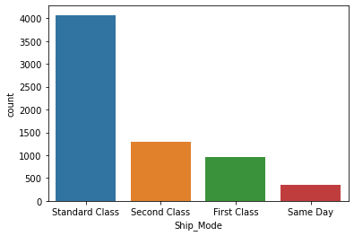

```python
sns.countplot(data['Ship_Mode'])
```